# Escalonamento Multidimensional

O escalonamento multidimensional é uma técnica de interdependência que permite mapear distâncias entre objetos.

A técnica do Escalonamento Multidimensional é usada para representar espacialmente uma matriz de proximidades (semelhança ou dissemelhança) entre uma série de objetos de modo que possam ser mais facilmente visualizados.

A técnica é apropriada para representar graficamente $n$ elementos em um espaço de dimensão menor do que o original, levando-se em conta a distância ou a similaridade que os elementos têm entre si.

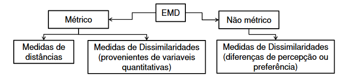

# Escalonamento Multidimensional Métrico

## Modelagem do Escalonamento Multidimensional Métrico

O escalonamento multidimensional métrico é feito conforme os seguintes passos:

1. Uma configuração inicial é estabelecida para os $n$ objetos em $k$. dimensões.
2. As distâncias euclidianas entre os objetos são calculadas para a configuração assumida. Seja $d_{ij}$ a distância entre o objeto $i$ e o objeto $j$ para esta configuração.
3. Uma regressão de $d_{ij}$ em $\delta_{ij}$ é feita onde, como mencionado acima, $d_{ij}$ é a distância entre o objeto $i$ e o objeto $j$, de acordo com os dados de entrada, e $\delta_{ij}$ é a célula da matriz, na linha $i$, coluna $j$. A regressão pode ser linear, polinomial ou monótona.
4. A qualidade de ajuste entre as distâncias de configuração e as disparidades é medida por uma estatística adequada.
5. As coordenadas de cada objeto são alteradas levemente de tal maneira que o stress é reduzido.

# Escalonamento Multidimensional Não-Métrico

Este tipo de escalonamento pode ser utilizado na situação em que objetiva-se estudar valores ordinais, e não numéricos. Esse método é invariante sob transformações monotônicas, ou seja, as coordenadas obtidas permaneçam as mesmas se valores numéricos das proximidades forem modificados, porém sem modificar a ordem dos postos.

### Modelagem Multidimensional Não-Métrico

$$d_{ij} = \hat{d}_{ij} + \varepsilon_{ij}$$

As disparidades são monotônicas com as proximidades observadas e, sujeitas a esta restrição, assemelham-se, tanto quanto possível, às distâncias ajustadas.

### Medidas de adequação do ajuste

Algumas medidas para avaliar o quanto as distâncias derivadas dos dados dissimilaridades se aproximam daqueles originais fornecidas pelos respondentes são:

- Stress, Kruskal

$$STRESS = \sqrt{\frac{\sum_i \sum_j (d_{ij} - \hat{d_{ij}})^2}{{\sum_i \sum_j \hat{d_{ij}}^2}}}$$

- Stress, Young

$$SSTRESS= \sqrt{\dfrac{\sum_i \sum_j (d_{ij}^2 - \hat{d_{ij}}^2)^2}{\sum_i \sum_j \hat{d_{ij}}^4}}$$

| STRESS | Adequação do Ajuste |
| --- | --- |
| 20% | Pobre |
| 10% | Razoável |
| 5% | Bom |
| 2,5% | Excelente |
| 0% | Perfeito |

# Escalonamento Multidimensional no R

## Métrico

```r
if(!require(MVar.pt)){install.packages("MVar.pt", repos = "https://cran.fiocruz.br/")}
if(!require(vegan)){install.packages("vegan", repos = "https://cran.fiocruz.br/")}
require(MVar.pt)
require(MASS)
require(vegan)
```

```r
dados1 <- read.csv2("distancias.csv", stringsAsFactors = F)
dados1 <- tibble::column_to_rownames(dados1, "Cidade")

metrico <- MDS(dados1)
```

[figure not shown]

```r
metrico1 <- cmdscale(as.matrix(dados1))
metrico2 <- isoMDS(as.matrix(dados1))
metrico1
```

```
##                     [,1]       [,2]
## Belo Horizonte -388.7006  1426.8416
## Brasília       -230.4658  -131.4459
## Campinas       -638.0251  -106.8173
## Curitiba       -645.0588   719.8081
## Manaus         -266.7333 -1769.1870
## Natal          3459.6103   295.9116
## Porto Alegre    341.2605  1238.4096
## Rio de Janeiro  897.6891   821.0767
## Salvador       1462.4843    70.1609
## São Luis       1677.4509 -1095.3849
```

```r
metrico2
```

```
## $points
##                     [,1]        [,2]
## Belo Horizonte -388.6987  1426.84058
## Brasília       -230.4630  -131.44530
## Campinas       -638.0247  -106.81732
## Curitiba       -645.0601   719.81039
## Manaus         -266.7336 -1769.19129
## Natal          3459.6037   295.91043
## Porto Alegre    341.2589  1238.41405
## Rio de Janeiro  897.6882   821.07862
## Salvador       1462.4873    70.16015
## São Luis       1677.4534 -1095.38686
##
## $stress
## [1] 25.9978
```

## Não métrico

```r
dados <- read.csv2("Trabalhos/Trabalho5_MontarAula/naometrico.csv", sep = ",")

dados <- tibble::column_to_rownames(dados, "X")

naometrico <- isoMDS(as.matrix(dados))
ef <- envfit(naometrico, dados, permu = 999)
ef
```

```
##
## ***VECTORS
##
##                 Dim1     Dim2     r2 Pr(>r)
## Hitler       0.89845  0.43907 0.6909  0.008 **
## Mussolini    0.91763  0.39744 0.7112  0.007 **
## Churchill   -0.11606 -0.99324 0.2859  0.223
## Eisenhower  -0.70678 -0.70744 0.4361  0.084 .
## Stalin       0.51830  0.85520 0.6898  0.002 **
## Attlee       0.30169 -0.95341 0.5545  0.020 *
## Franco       0.98764  0.15673 0.4846  0.055 .
## De.Gaulle   -0.07882 -0.99689 0.0271  0.885
## Tse.Tung    -0.72164  0.69227 0.8207  0.001 ***
## Truman      -0.97869 -0.20536 0.7920  0.002 **
## Chamberlain  0.51591 -0.85665 0.7938  0.002 **
## Tito        -0.99864  0.05220 0.2963  0.202
## ---
## Signif. codes:  0 '***' 0.001 '**' 0.01 '*' 0.05 '.' 0.1 ' ' 1
## Permutation: free
## Number of permutations: 999
```

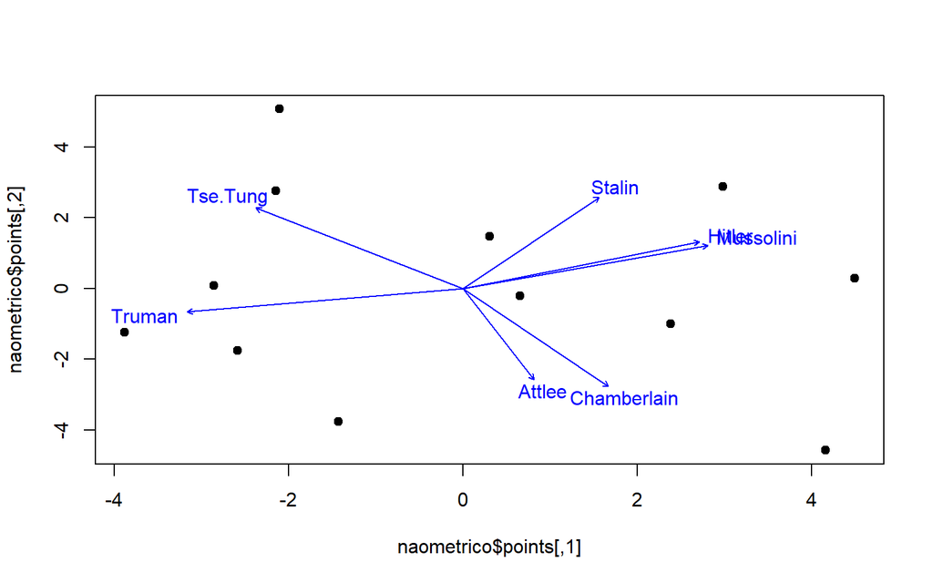

```r
plot(naometrico$points, pch = 19)
plot(ef, p.max = 0.05) # somente os mais significativas
```

## Exercício

Realize o escalonamento multidimensional com a base `swiss`, do R.

Camila Simões, Jessyka Goltara, Leonardo Filgueira, Beatriz Jardim

7 de novembro de 2018